# Practical Machine Learning Course - Prediction Assignment Writeup

ElenaKush

April 01, 2020

## Executive summary

In this project, our goal was to predict the manner in which 6 people did the barbell lifts.

We used data from accelerometers on the belt, forearm, arm, and dumbell of 6 people, who were asked to perform barbell lifts in 5 different fashions:

- exactly according to the specification (class A),
- throwing the elbows to the front (class B),
- lifting the dumbbell only halfway (class C),
- lowering the dumbbell only halfway (class D)
- throwing the hips to the front (class E).

In the project we explored data, preprocessed it for modelling, chose an appropriate validation strategy, built several models and evaluated their quality.

## Environment settings

We loaded the following libraries: caret, dplyr, tidyr, lubridate, reshape2, ggplot2, plotly, ranger and rpart.plot.

## Data Loading

We loaded data form the following sources:

- train_set - https://d396qusza40orc.cloudfront.net/predmachlearn/pml-training.csv
- test_set - https://d396qusza40orc.cloudfront.net/predmachlearn/pml-testing.csv

## EDA

```r
rbind(train_set = dim(train_set), test_set = dim(test_set))
```

```
           [,1] [,2]
train_set 19622  160
test_set     20  160
```

Both training and test sets have 160 variables. In the test set there are only 20 observation, in the train set about 20K observations though.

There are the following types of variables:

- X - number of observation (row);
- user_name (6 people, who were asked to perform barbell lifts);
- raw data from accelerometers on the belt, forearm, arm, and dumbell;
- aggerated data from accelerometers;
- timestamp (when the exercise was being performed);
- classe (target variable - the fashion in that the exercise was performed);
- number of window.

Our target variable is a factor with 5 classes. So, we need to solve a multiclass classification problem.

We need to figure out how balanced our dataset is. So, we can choose an appropriate model type, validation strategy and train_set preprocess procedures.

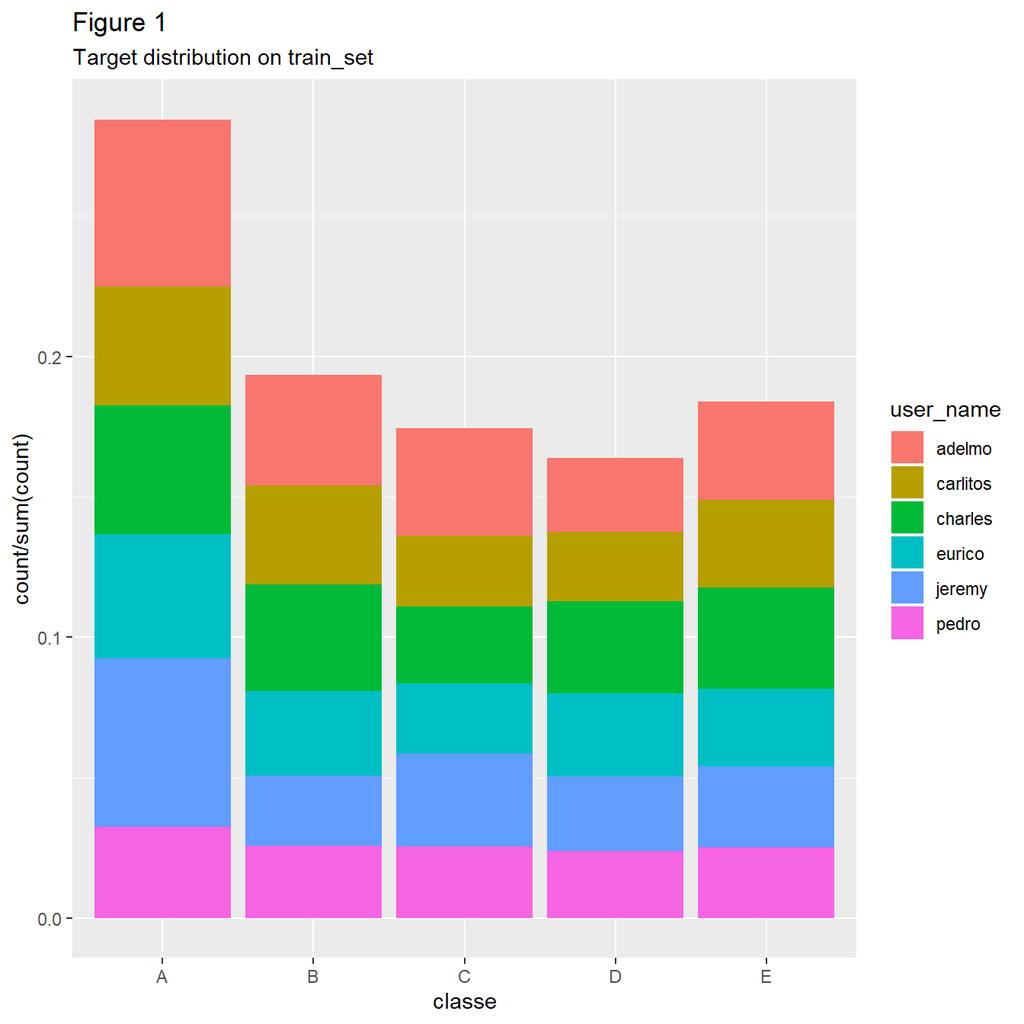

```r
ggplot(data = train_set, aes(x = classe, fill = user_name)) +
    geom_bar(aes(y = ..count../sum(..count..))) +
    labs(title = "Figure 1",
         subtitle = "Target distribution on train_set")
```

The target variable can be considered as a balanced one. There is no need to generate new data to get a more balanced dataset.

Let’s check how the observations are sorted in the train_set.

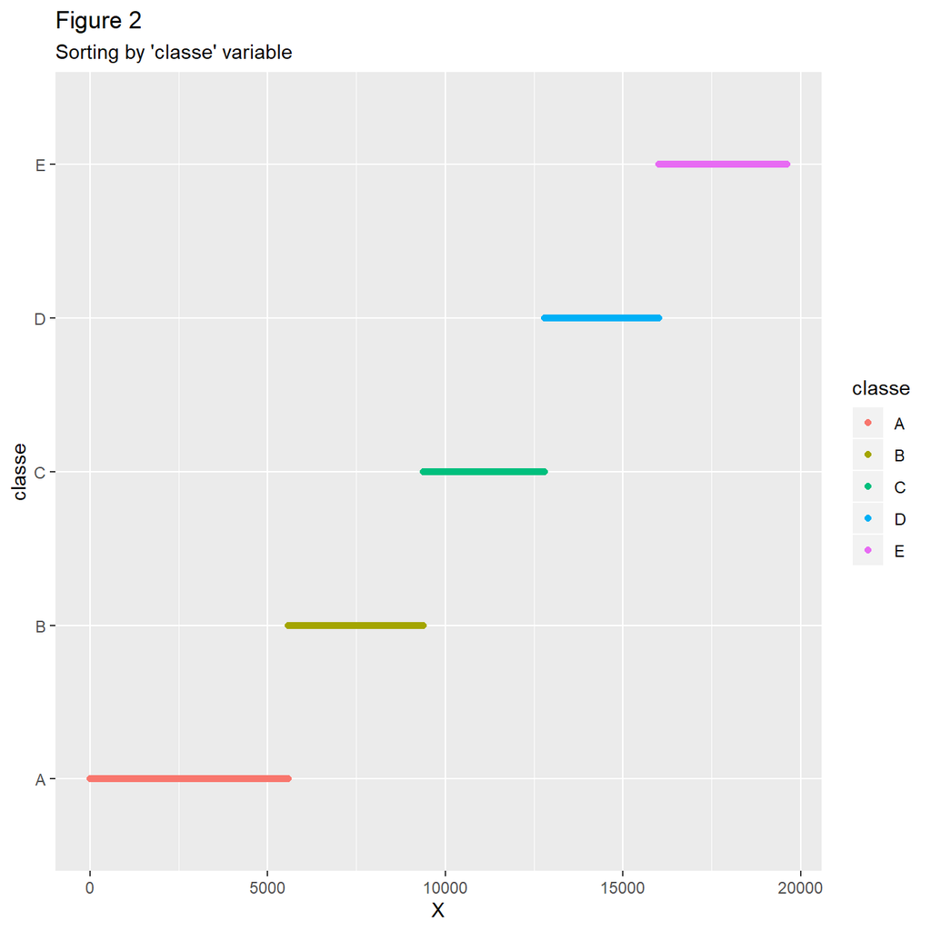

```r
ggplot(data = train_set, aes(x = X, y = classe, color = classe)) + ## by classe
  geom_point() +
    labs(title = "Figure 2",
         subtitle = "Sorting by 'classe' variable")
```

The observations are clearly sorted by a target. For the training there is a need to exclude the X variable which indicates the number of observation (row).

Let’s check the observation sorting by timestamp and user_name.

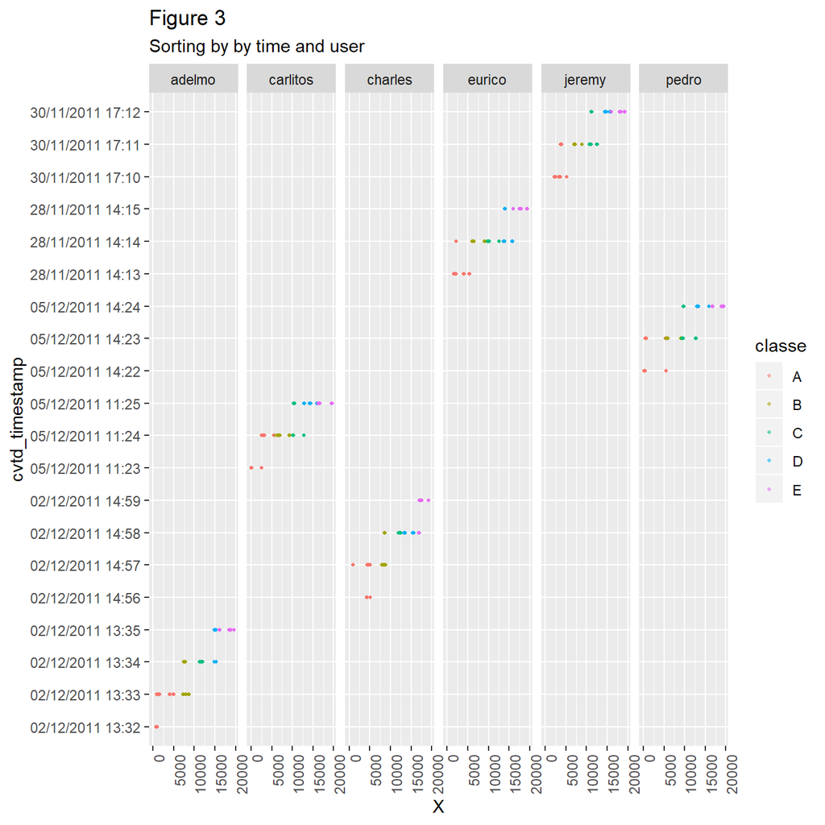

```r
ggplot(data = train_set, aes(x = X, y = cvtd_timestamp, color = classe)) + ## by cvtd_timestamp
  geom_point(alpha = 0.5, size = 0.8) +
    facet_grid(. ~ user_name) +
    theme(axis.text.x = element_text(angle = 90, hjust = 1)) +
    labs(title = "Figure 3",
         subtitle = "Sorting by by time and user")
```

Each user was performing the exercises in the same order (A -> B -> C -> D -> E).

Each user performed the exercises in his own period of time, so the timestamps for different users do not overlap each other.

These two findings indicate the way of dataset preparation and can lead to leakage in predictions. So, there is a need to exclude timestamp for fair modelling purposes.

Let’s check whether the target variable can be changed within one window.

```r
## We will make a pivot table with num_window in rows, classe in columns and number of observations in each num_window - classe combination
spread_df <- train_set %>%
  count(classe, num_window) %>%
  spread(classe, n, fill = 0)

spread_df$sum <- rowSums(spread_df[, -1])  ## count sum in each row (total observations per window)

## Hypothetically, if there is only one class within the window, in one column should be value which equals total observations per window, in others - zeros.
## We will find a diffeence between total observations per window and number of observations in the 1st class (1st colums).
## If there is a difference (!=0) we move to the 2nd class and so on.
spread_df$dif <- 0
for(i in 1:nrow(spread_df)) {
    if (spread_df[i, 2] != 0) {
      spread_df$dif[i] <- spread_df[i, 2] - spread_df[i, 7]
      } else if (spread_df[i, 3] != 0) {
          spread_df$dif[i] <- spread_df[i, 3] - spread_df[i, 7]
          } else if (spread_df[i, 4] != 0) {
              spread_df$dif[i] <- spread_df[i, 4] - spread_df[i, 7]
          } else if (spread_df[i, 5] != 0) {
              spread_df$dif[i] <- spread_df[i, 5] - spread_df[i, 7]
          } else if (spread_df[i, 6] != 0) {
              spread_df$dif[i] <- spread_df[i, 6] - spread_df[i, 7]
                      } else {
                          spread_df$dif <- NULL
                      }
}

## We will find the min and max in difference
summary(unlist(spread_df$dif))
```

```
   Min. 1st Qu.  Median    Mean 3rd Qu.    Max.
      0       0       0       0       0       0
```

We prooved that only one class is observed within one window. It means if one observation from the window is used for testing and all other observations from the same window are used for the training, the variable num_window should be a good predictor. Knowing this variable is unfair, so we should exclude num_window variable.

Let’s check the structure of train_set.

```r
str(train_set) ## many numeric variable are in fact factors
summary(train_set) ## many factors contain a lot of gaps and errors like #DIV/0
```

Most of aggregates (max, min, avg, std, etc.) are recorded as factors, although they should be numeric. They contain a lot of gaps and errors like #DIV/0. It may affect the model quality. SO, we would rather exclude aggregates because most sophisticated models such as decision trees or random forest do not need them.

*You can find the full EDA in the file EDA.html*.

## Data Preparation

To avoid a leakage, we have to exclude:

- the X variable that indicates a row number;
- the raw_timestamp variables that indicates a date/time of exercise;
- num_window variable that can lead to unfair prediction.

We exclude as well all aggregates as the sophisticated prediction approaches (such as random forest and decision tree) do not require the special data preparation (s. https://towardsdatascience.com/comparative-study-on-classic-machine-learning-algorithms-24f9ff6ab222).

We prepared both train_set and test_set the same way.

```r
trunc_train_set <- train_set[, c(2, 6, 8:11, 37:49, 60:68, 84:86, 102, 113:124, 140, 151:160)]
dim(trunc_train_set)
```

```
[1] 19622    55
```

```r
trunc_test_set <- test_set[, c(2, 6, 8:11, 37:49, 60:68, 84:86, 102, 113:124, 140, 151:160)]
dim(trunc_test_set)
```

```
[1] 20 55
```

## Validation strategy

We will randomly pick observations from train_set and hold them out for the validation. But we will leave the same proportion of classes in all sets.

The function createDataPartition can be used to create balanced splits of the data. If the target is a factor (as in our case), the random sampling occurs within each class and should preserve the overall class distribution of the data (s. https://topepo.github.io/caret/data-splitting.html#simple-splitting-based-on-the-outcome).

We will train our model on 80% of train_set. The rest we will equally divide into dev_set (10%) and valid_set (10%). The dev_set we will use to tune hyperparameters. The valid_set we will use to check whether the model has no overfitting.

```r
set.seed(12345)
trainIndex <- createDataPartition(trunc_train_set$classe, p = .8, list = FALSE)
my_train_set <- trunc_train_set[trainIndex, ]
set.seed(12345)
devIndex <- createDataPartition(trunc_train_set[-trainIndex, 55], p = .5, list = FALSE)
my_dev_set <- trunc_train_set[-trainIndex, ][devIndex, ]
my_valid_set <- trunc_train_set[-trainIndex, ][-devIndex, ]
```

Moreover, we will use k-fold cross validation to get more robust results, while training our model. My_train_set will be divided into 5 subsets, and the holdout method is repeated 5 times. Each time, one of the 5 subsets is used for testing and the other 4 subsets are put together to form a training set. Then the average error across 5 trials is computed. The advantage of this method is that it matters less how the data gets divided. Every data point gets to be in a test set exactly once, and gets to be in a training set 4 times. The variance of the resulting estimate is reduced as number of trials is bigger (https://www.cs.cmu.edu/~schneide/tut5/node42.html).

We will save CV parameters:

```r
control <- trainControl(method = "cv", number = 5)
```

## Prediction

We have a multiclass prediction issue.  
For this task, the appropriate model type will be tree-based algorithms or Neural Networks. (https://stats.stackexchange.com/questions/318520/many-binary-classifiers-vs-single-multiclass-classifier, https://www.cs.utah.edu/~piyush/teaching/aly05multiclass.pdf).  
Let’s try a decision (classification) tree first and then a random forest as a collection of many decision trees.

```r
set.seed(12345)
system.time(dtree_fit <- train(classe ~ ., data = my_train_set, method = "rpart",
                   parms = list(split = "information"),
                   trControl = control))
```

```
   user  system elapsed
   7.57    0.05    7.77
```

```r
dtree_fit
```

```
CART

15699 samples
   54 predictor
    5 classes: 'A', 'B', 'C', 'D', 'E'

No pre-processing
Resampling: Cross-Validated (5 fold)
Summary of sample sizes: 12560, 12559, 12559, 12559, 12559
Resampling results across tuning parameters:

  cp          Accuracy   Kappa
  0.03515799  0.5275502  0.39482698
  0.06067349  0.3659469  0.12469158
  0.11419671  0.3488131  0.09862192

Accuracy was used to select the optimal model using the largest value.
The final value used for the model was cp = 0.03515799.
```

The expected OOB error for classification tree is 0.4724498.  
The accuracy on the train set is 0.5275502.

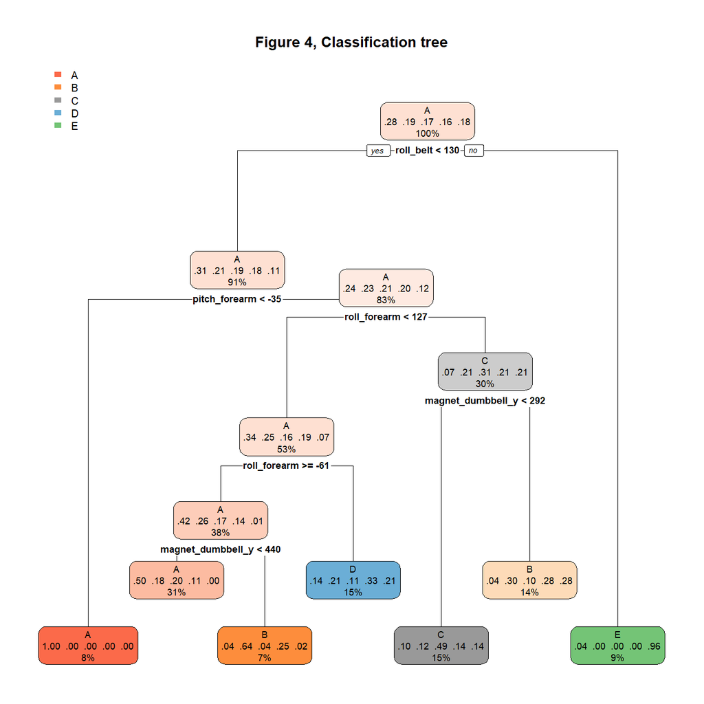

```r
rpart.plot(dtree_fit$finalModel,
           main = "Figure 4, Classification tree")
```

The following predictors were used as relevan ones: Roll_bell, Pitch_forearm, roll_forearm, magnet_dumbbell_y.

Let’s predict classes on a my_dev_set and my_valid_set using classification tree model.

```r
dtree_dev_pred <- predict(dtree_fit, my_dev_set[, -55])
confusionMatrix(dtree_dev_pred, my_dev_set[, 55])
```

```
Confusion Matrix and Statistics

          Reference
Prediction   A   B   C   D   E
         A 477 103 134  63   3
         B  19 185  27 103  91
         C  22  32 141  45  39
         D  32  60  40 111  48
         E   8   0   0   0 180

Overall Statistics

               Accuracy : 0.5573
                 95% CI : (0.535, 0.5794)
    No Information Rate : 0.2843
    P-Value [Acc > NIR] : < 2.2e-16

                  Kappa : 0.4313

 Mcnemar's Test P-Value : < 2.2e-16

Statistics by Class:

                     Class: A Class: B Class: C Class: D Class: E
Sensitivity            0.8548  0.48684  0.41228  0.34472  0.49861
Specificity            0.7843  0.84839  0.91487  0.89031  0.99501
Pos Pred Value         0.6115  0.43529  0.50538  0.38144  0.95745
Neg Pred Value         0.9315  0.87321  0.88064  0.87380  0.89803
Prevalence             0.2843  0.19358  0.17422  0.16403  0.18390
Detection Rate         0.2430  0.09424  0.07183  0.05655  0.09170
Detection Prevalence   0.3974  0.21651  0.14213  0.14824  0.09577
Balanced Accuracy      0.8196  0.66762  0.66357  0.61752  0.74681
```

```r
confusionMatrix(dtree_dev_pred, my_dev_set[, 55])
```

```
Confusion Matrix and Statistics

          Reference
Prediction   A   B   C   D   E
         A 477 103 134  63   3
         B  19 185  27 103  91
         C  22  32 141  45  39
         D  32  60  40 111  48
         E   8   0   0   0 180

Overall Statistics

               Accuracy : 0.5573
                 95% CI : (0.535, 0.5794)
    No Information Rate : 0.2843
    P-Value [Acc > NIR] : < 2.2e-16

                  Kappa : 0.4313

 Mcnemar's Test P-Value : < 2.2e-16

Statistics by Class:

                     Class: A Class: B Class: C Class: D Class: E
Sensitivity            0.8548  0.48684  0.41228  0.34472  0.49861
Specificity            0.7843  0.84839  0.91487  0.89031  0.99501
Pos Pred Value         0.6115  0.43529  0.50538  0.38144  0.95745
Neg Pred Value         0.9315  0.87321  0.88064  0.87380  0.89803
Prevalence             0.2843  0.19358  0.17422  0.16403  0.18390
Detection Rate         0.2430  0.09424  0.07183  0.05655  0.09170
Detection Prevalence   0.3974  0.21651  0.14213  0.14824  0.09577
Balanced Accuracy      0.8196  0.66762  0.66357  0.61752  0.74681
```

Accuracy on my_dev_set is 0.5573102.

```r
dtree_valid_pred <- predict(dtree_fit, my_valid_set[, -55])
confusionMatrix(dtree_valid_pred, my_valid_set[, 55])
```

```
Confusion Matrix and Statistics

          Reference
Prediction   A   B   C   D   E
         A 469 111 135  67   3
         B  18 164  29 120  87
         C  22  28 137  49  42
         D  41  76  41  85  58
         E   8   0   0   0 170

Overall Statistics

               Accuracy : 0.523
                 95% CI : (0.5006, 0.5453)
    No Information Rate : 0.2847
    P-Value [Acc > NIR] : < 2.2e-16

                  Kappa : 0.387

 Mcnemar's Test P-Value : < 2.2e-16

Statistics by Class:

                     Class: A Class: B Class: C Class: D Class: E
Sensitivity            0.8405  0.43272   0.4006  0.26480  0.47222
Specificity            0.7746  0.83934   0.9129  0.86821  0.99500
Pos Pred Value         0.5975  0.39234   0.4928  0.28239  0.95506
Neg Pred Value         0.9243  0.86057   0.8781  0.85775  0.89338
Prevalence             0.2847  0.19337   0.1745  0.16378  0.18367
Detection Rate         0.2393  0.08367   0.0699  0.04337  0.08673
Detection Prevalence   0.4005  0.21327   0.1418  0.15357  0.09082
Balanced Accuracy      0.8076  0.63603   0.6567  0.56650  0.73361
```

Accuracy on my_valid_set is 0.5229592.

Similar accuracy on the dev and valid sets (0.5573102 vs. 0.5229592) proves the fact there is no overfitting in the classification tree model.

Let’s try a random forest algo.  
We will use ranger method to speed up the training. We chose this method due to the following facts:  
* the rf method is slow;  
* due to cross validation the random forest algorithm has to be rerun from scratch 5 times which means it takes 5 times as much computation to make an evaluation;  
* the ranger method is faster then rf.

```r
set.seed(12345)
system.time(rf_fit <- train(classe ~ ., data = my_train_set, method = 'ranger',
                            importance = "permutation",
                            trControl = control))
```

```
   user  system elapsed
2212.30    5.87  616.78
```

```r
rf_fit
```

```
Random Forest

15699 samples
   54 predictor
    5 classes: 'A', 'B', 'C', 'D', 'E'

No pre-processing
Resampling: Cross-Validated (5 fold)
Summary of sample sizes: 12560, 12559, 12559, 12559, 12559
Resampling results across tuning parameters:

  mtry  splitrule   Accuracy   Kappa
   2    gini        0.9912098  0.9888805
   2    extratrees  0.9877701  0.9845277
  30    gini        0.9927384  0.9908142
  30    extratrees  0.9951590  0.9938767
  58    gini        0.9854769  0.9816274
  58    extratrees  0.9956049  0.9944406

Tuning parameter 'min.node.size' was held constant at a value of 1
Accuracy was used to select the optimal model using the largest value.
The final values used for the model were mtry = 58, splitrule = extratrees
 and min.node.size = 1.
```

```r
rf_fit$finalModel
```

```
Ranger result

Call:
 ranger::ranger(dependent.variable.name = ".outcome", data = x,      mtry = min(param$mtry, ncol(x)), min.node.size = param$min.node.size,      splitrule = as.character(param$splitrule), write.forest = TRUE,      probability = classProbs, ...)

Type:                             Classification
Number of trees:                  500
Sample size:                      15699
Number of independent variables:  58
Mtry:                             58
Target node size:                 1
Variable importance mode:         permutation
Splitrule:                        extratrees
Number of random splits:          1
OOB prediction error:             0.32 %
```

The expected OOB error for random forest is 0.0032486.  
The accuracy on the train set is 0.9956049.

```r
varImp(rf_fit)
```

```
ranger variable importance

  only 20 most important variables shown (out of 58)

                     Overall
magnet_dumbbell_z     100.00
pitch_forearm          99.74
roll_forearm           89.21
yaw_belt               79.50
roll_belt              76.29
roll_dumbbell          74.77
magnet_dumbbell_y      71.19
magnet_arm_x           62.72
magnet_dumbbell_x      61.29
pitch_belt             48.10
magnet_belt_z          43.41
magnet_belt_y          41.96
accel_forearm_x        34.85
accel_dumbbell_y       34.17
accel_dumbbell_z       33.93
yaw_dumbbell           33.50
total_accel_dumbbell   30.04
user_nameeurico        29.46
roll_arm               27.79
accel_belt_z           26.74
```

The following predictors were used as relevan ones: magnet_dumbbell_z, pitch_forearm, roll_forearm, yaw_belt, roll_belt. They have similar importance measure which tells there is no leakage in the data.

Let’s predict classes on a my_dev_set and my_valid_set using random forest model.

```r
rf_dev_pred <- predict(rf_fit, my_dev_set[, -55])
confusionMatrix(rf_dev_pred, my_dev_set[, 55])
```

```
Confusion Matrix and Statistics

          Reference
Prediction   A   B   C   D   E
         A 558   0   0   0   0
         B   0 380   2   0   0
         C   0   0 340   3   0
         D   0   0   0 318   0
         E   0   0   0   1 361

Overall Statistics

               Accuracy : 0.9969
                 95% CI : (0.9934, 0.9989)
    No Information Rate : 0.2843
    P-Value [Acc > NIR] : < 2.2e-16

                  Kappa : 0.9961

 Mcnemar's Test P-Value : NA

Statistics by Class:

                     Class: A Class: B Class: C Class: D Class: E
Sensitivity            1.0000   1.0000   0.9942   0.9876   1.0000
Specificity            1.0000   0.9987   0.9981   1.0000   0.9994
Pos Pred Value         1.0000   0.9948   0.9913   1.0000   0.9972
Neg Pred Value         1.0000   1.0000   0.9988   0.9976   1.0000
Prevalence             0.2843   0.1936   0.1742   0.1640   0.1839
Detection Rate         0.2843   0.1936   0.1732   0.1620   0.1839
Detection Prevalence   0.2843   0.1946   0.1747   0.1620   0.1844
Balanced Accuracy      1.0000   0.9994   0.9962   0.9938   0.9997
```

The Accuracy on my_dev_set is 0.9969435.

```r
rf_valid_pred <- predict(rf_fit, my_valid_set[, -55])
confusionMatrix(rf_valid_pred, my_valid_set[, 55])
```

```
Confusion Matrix and Statistics

          Reference
Prediction   A   B   C   D   E
         A 558   1   0   0   0
         B   0 378   2   0   0
         C   0   0 340   4   0
         D   0   0   0 316   0
         E   0   0   0   1 360

Overall Statistics

               Accuracy : 0.9959
                 95% CI : (0.992, 0.9982)
    No Information Rate : 0.2847
    P-Value [Acc > NIR] : < 2.2e-16

                  Kappa : 0.9948

 Mcnemar's Test P-Value : NA

Statistics by Class:

                     Class: A Class: B Class: C Class: D Class: E
Sensitivity            1.0000   0.9974   0.9942   0.9844   1.0000
Specificity            0.9993   0.9987   0.9975   1.0000   0.9994
Pos Pred Value         0.9982   0.9947   0.9884   1.0000   0.9972
Neg Pred Value         1.0000   0.9994   0.9988   0.9970   1.0000
Prevalence             0.2847   0.1934   0.1745   0.1638   0.1837
Detection Rate         0.2847   0.1929   0.1735   0.1612   0.1837
Detection Prevalence   0.2852   0.1939   0.1755   0.1612   0.1842
Balanced Accuracy      0.9996   0.9980   0.9958   0.9922   0.9997
```

The Accuracy on my_valid_set is 0.9959184.

Similar accuracy on the dev and valid sets (0.9969435 vs. 0.9959184) proves the fact there is no overfitting in the random forest model.

The random forest model has significantly better quality than the classification tree model (the OOB error is smaller).

OOB error for:  
* classification tree = 0.4724498;  
* random forest = 0.0032486.

The validation on the dev and valid sets confirmed that as well.

## Predictions on the test set

For the predictions on the ‘hidden’ test set we will use the random forest model:

```r
rf_test_pred <- predict(rf_fit, trunc_test_set)
trunc_test_set %>%
    select(problem_id) %>%
    mutate(pred_class = rf_test_pred)
```

```
   problem_id pred_class
1           1          B
2           2          A
3           3          B
4           4          A
5           5          A
6           6          E
7           7          D
8           8          B
9           9          A
10         10          A
11         11          B
12         12          C
13         13          B
14         14          A
15         15          E
16         16          E
17         17          A
18         18          B
19         19          B
20         20          B
```

## Take care, stay home, stay safe.

*Word count via wordcountaddin:::text_stats() - 1435 (koRpus), 1405 (stringi)*